# Starbucks Capstone Challenge

### Introduction

This data set contains simulated data that mimics customer behavior on the Starbucks rewards mobile app. Once every few days, Starbucks sends out an offer to users of the mobile app. An offer can be merely an advertisement for a drink or an actual offer such as a discount or BOGO (buy one get one free). Some users might not receive any offer during certain weeks.

Not all users receive the same offer, and that is the challenge to solve with this data set.

Your task is to combine transaction, demographic and offer data to determine which demographic groups respond best to which offer type. This data set is a simplified version of the real Starbucks app because the underlying simulator only has one product whereas Starbucks actually sells dozens of products.

Every offer has a validity period before the offer expires. As an example, a BOGO offer might be valid for only 5 days. You'll see in the data set that informational offers have a validity period even though these ads are merely providing information about a product; for example, if an informational offer has 7 days of validity, you can assume the customer is feeling the influence of the offer for 7 days after receiving the advertisement.

You'll be given transactional data showing user purchases made on the app including the timestamp of purchase and the amount of money spent on a purchase. This transactional data also has a record for each offer that a user receives as well as a record for when a user actually views the offer. There are also records for when a user completes an offer.

Keep in mind as well that someone using the app might make a purchase through the app without having received an offer or seen an offer.

### Example

To give an example, a user could receive a discount offer buy 10 dollars get 2 off on Monday. The offer is valid for 10 days from receipt. If the customer accumulates at least 10 dollars in purchases during the validity period, the customer completes the offer.

However, there are a few things to watch out for in this data set. Customers do not opt into the offers that they receive; in other words, a user can receive an offer, never actually view the offer, and still complete the offer. For example, a user might receive the "buy 10 dollars get 2 dollars off offer", but the user never opens the offer during the 10 day validity period. The customer spends 15 dollars during those ten days. There will be an offer completion record in the data set; however, the customer was not influenced by the offer because the customer never viewed the offer.

### Cleaning

This makes data cleaning especially important and tricky.

You'll also want to take into account that some demographic groups will make purchases even if they don't receive an offer. From a business perspective, if a customer is going to make a 10 dollar purchase without an offer anyway, you wouldn't want to send a buy 10 dollars get 2 dollars off offer. You'll want to try to assess what a certain demographic group will buy when not receiving any offers.

### Final Advice

Because this is a capstone project, you are free to analyze the data any way you see fit. For example, you could build a machine learning model that predicts how much someone will spend based on demographics and offer type. Or you could build a model that predicts whether or not someone will respond to an offer. Or, you don't need to build a machine learning model at all. You could develop a set of heuristics that determine what offer you should send to each customer (i.e., 75 percent of women customers who were 35 years old responded to offer A vs 40 percent from the same demographic to offer B, so send offer A).

# Data Sets

The data is contained in three files:

- portfolio.json - containing offer ids and meta data about each offer (duration, type, etc.)
- profile.json - demographic data for each customer
- transcript.json - records for transactions, offers received, offers viewed, and offers completed

Here is the schema and explanation of each variable in the files:

**portfolio.json**

- id (string) - offer id
- offer_type (string) - type of offer ie BOGO, discount, informational
- difficulty (int) - minimum required spend to complete an offer
- reward (int) - reward given for completing an offer
- duration (int) - time for offer to be open, in days
- channels (list of strings)

**profile.json**

- age (int) - age of the customer
- became_member_on (int) - date when customer created an app account
- gender (str) - gender of the customer (note some entries contain 'O' for other rather than M or F)
- id (str) - customer id
- income (float) - customer's income

**transcript.json**

- event (str) - record description (ie transaction, offer received, offer viewed, etc.)
- person (str) - customer id
- time (int) - time in hours since start of test. The data begins at time t=0
- value - (dict of strings) - either an offer id or transaction amount depending on the record

**Note:** If you are using the workspace, you will need to go to the terminal and run the command `conda update pandas` before reading in the files. This is because the version of pandas in the workspace cannot read in the transcript.json file correctly, but the newest version of pandas can. You can access the termnal from the orange icon in the top left of this notebook.

You can see how to access the terminal and how the install works using the two images below. First you need to access the terminal:

[figure not shown]

Then you will want to run the above command:

[figure not shown]

Finally, when you enter back into the notebook (use the jupyter icon again), you should be able to run the below cell without any errors.

# Dataset Overview

- The program used to create the data simulates how people make purchasing decisions and how those decisions are influenced by promotional offers.
- Each person in the simulation has some hidden traits that influence their purchasing patterns and are associated with their observable traits. People produce various events, including receiving offers, opening offers, and making purchases.

# TASK

**The basic task is to use the data to identify which groups of people are most responsive to each type of offer, and how best to present each type of offer.**

```python
!pip install seaborn -U
```

```
    100% |████████████████████████████████| 215kB 23.6MB/s ta 0:00:01
  Found existing installation: seaborn 0.8.1
    Uninstalling seaborn-0.8.1:
      Successfully uninstalled seaborn-0.8.1
```

```python
import pandas as pd
import numpy as np
import math
import json
import matplotlib
import matplotlib.pyplot as plt
import seaborn as sns
% matplotlib inline

# read in the json files
portfolio = pd.read_json('data/portfolio.json', orient='records', lines=True)
profile = pd.read_json('data/profile.json', orient='records', lines=True)
transcript = pd.read_json('data/transcript.json', orient='records', lines=True)
```

# Data preparation

```python
portfolio.head()
```

|  | channels | difficulty | duration | id | offer_type | reward |
| --- | --- | --- | --- | --- | --- | --- |
| 0 | [email, mobile, social] | 10 | 7 | ae264e3637204a6fb9bb56bc8210ddfd | bogo | 10 |
| 1 | [web, email, mobile, social] | 10 | 5 | 4d5c57ea9a6940dd891ad53e9dbe8da0 | bogo | 10 |
| 2 | [web, email, mobile] | 0 | 4 | 3f207df678b143eea3cee63160fa8bed | informational | 0 |
| 3 | [web, email, mobile] | 5 | 7 | 9b98b8c7a33c4b65b9aebfe6a799e6d9 | bogo | 5 |
| 4 | [web, email] | 20 | 10 | 0b1e1539f2cc45b7b9fa7c272da2e1d7 | discount | 5 |

```python
# null check
portfolio.isnull().sum()
```

```
channels      0
difficulty    0
duration      0
id            0
offer_type    0
reward        0
dtype: int64
```

```python
# one-hot encording for channels
for index, row in portfolio.iterrows():
    for channel in ['web', 'email', 'social', 'mobile']:
        if channel in portfolio.loc[index, 'channels']:
            portfolio.loc[index, channel] = 1
        else:
            portfolio.loc[index, channel] = 0
```

```python
for index, row in portfolio.iterrows():
    for offertype in ['bogo', 'informational', 'discount']:
        if offertype in portfolio.loc[index, 'offer_type']:
            portfolio.loc[index, offertype] = 1
        else:
            portfolio.loc[index, offertype] = 0
```

```python
portfolio
```

|  | channels | difficulty | duration | id | offer_type | reward | web | email | social | mobile | bogo | informational | discount |
| --- | --- | --- | --- | --- | --- | --- | --- | --- | --- | --- | --- | --- | --- |
| 0 | [email, mobile, social] | 10 | 7 | ae264e3637204a6fb9bb56bc8210ddfd | bogo | 10 | 0.0 | 1.0 | 1.0 | 1.0 | 1.0 | 0.0 | 0.0 |
| 1 | [web, email, mobile, social] | 10 | 5 | 4d5c57ea9a6940dd891ad53e9dbe8da0 | bogo | 10 | 1.0 | 1.0 | 1.0 | 1.0 | 1.0 | 0.0 | 0.0 |
| 2 | [web, email, mobile] | 0 | 4 | 3f207df678b143eea3cee63160fa8bed | informational | 0 | 1.0 | 1.0 | 0.0 | 1.0 | 0.0 | 1.0 | 0.0 |
| 3 | [web, email, mobile] | 5 | 7 | 9b98b8c7a33c4b65b9aebfe6a799e6d9 | bogo | 5 | 1.0 | 1.0 | 0.0 | 1.0 | 1.0 | 0.0 | 0.0 |
| 4 | [web, email] | 20 | 10 | 0b1e1539f2cc45b7b9fa7c272da2e1d7 | discount | 5 | 1.0 | 1.0 | 0.0 | 0.0 | 0.0 | 0.0 | 1.0 |
| 5 | [web, email, mobile, social] | 7 | 7 | 2298d6c36e964ae4a3e7e9706d1fb8c2 | discount | 3 | 1.0 | 1.0 | 1.0 | 1.0 | 0.0 | 0.0 | 1.0 |
| 6 | [web, email, mobile, social] | 10 | 10 | fafdcd668e3743c1bb461111dcafc2a4 | discount | 2 | 1.0 | 1.0 | 1.0 | 1.0 | 0.0 | 0.0 | 1.0 |
| 7 | [email, mobile, social] | 0 | 3 | 5a8bc65990b245e5a138643cd4eb9837 | informational | 0 | 0.0 | 1.0 | 1.0 | 1.0 | 0.0 | 1.0 | 0.0 |
| 8 | [web, email, mobile, social] | 5 | 5 | f19421c1d4aa40978ebb69ca19b0e20d | bogo | 5 | 1.0 | 1.0 | 1.0 | 1.0 | 1.0 | 0.0 | 0.0 |
| 9 | [web, email, mobile] | 10 | 7 | 2906b810c7d4411798c6938adc9daaa5 | discount | 2 | 1.0 | 1.0 | 0.0 | 1.0 | 0.0 | 0.0 | 1.0 |

```python
profile.head()
```

|  | age | became_member_on | gender | id | income |
| --- | --- | --- | --- | --- | --- |
| 0 | 118 | 20170212 | None | 68be06ca386d4c31939f3a4f0e3dd783 | NaN |
| 1 | 55 | 20170715 | F | 0610b486422d4921ae7d2bf64640c50b | 112000.0 |
| 2 | 118 | 20180712 | None | 38fe809add3b4fcf9315a9694bb96ff5 | NaN |
| 3 | 75 | 20170509 | F | 78afa995795e4d85b5d9ceeca43f5fef | 100000.0 |
| 4 | 118 | 20170804 | None | a03223e636434f42ac4c3df47e8bac43 | NaN |

```python
profile.shape
```

```
(17000, 5)
```

```python
profile.isnull().sum()
```

```
age                    0
became_member_on       0
gender              2175
id                     0
income              2175
dtype: int64
```

```python
# change into datetime
type(profile['became_member_on'][1]) # this is numpy int64 NOT strings
```

```
numpy.int64
```

```python
# change the datatype into str
profile['became_member_on'] = profile['became_member_on'].astype(str)
```

```python
# make a column for year
profile['membership_year'] = profile['became_member_on'].apply(lambda x: x[0:4])
```

```python
# change into datetieme
profile['became_member_on'] = pd.to_datetime(profile['became_member_on'])
```

```python
type(profile['became_member_on'][1])
```

```
pandas._libs.tslibs.timestamps.Timestamp
```

```python
# delete data with null
profile.dropna(axis='index', how='any', inplace=True)
```

```python
profile.shape
```

```
(14825, 6)
```

```python
profile.head()
```

|  | age | became_member_on | gender | id | income | membership_year |
| --- | --- | --- | --- | --- | --- | --- |
| 1 | 55 | 2017-07-15 | F | 0610b486422d4921ae7d2bf64640c50b | 112000.0 | 2017 |
| 3 | 75 | 2017-05-09 | F | 78afa995795e4d85b5d9ceeca43f5fef | 100000.0 | 2017 |
| 5 | 68 | 2018-04-26 | M | e2127556f4f64592b11af22de27a7932 | 70000.0 | 2018 |
| 8 | 65 | 2018-02-09 | M | 389bc3fa690240e798340f5a15918d5c | 53000.0 | 2018 |
| 12 | 58 | 2017-11-11 | M | 2eeac8d8feae4a8cad5a6af0499a211d | 51000.0 | 2017 |

```python
transcript.head()
```

|  | event | person | time | value |
| --- | --- | --- | --- | --- |
| 0 | offer received | 78afa995795e4d85b5d9ceeca43f5fef | 0 | {'offer id': '9b98b8c7a33c4b65b9aebfe6a799e6d9'} |
| 1 | offer received | a03223e636434f42ac4c3df47e8bac43 | 0 | {'offer id': '0b1e1539f2cc45b7b9fa7c272da2e1d7'} |
| 2 | offer received | e2127556f4f64592b11af22de27a7932 | 0 | {'offer id': '2906b810c7d4411798c6938adc9daaa5'} |
| 3 | offer received | 8ec6ce2a7e7949b1bf142def7d0e0586 | 0 | {'offer id': 'fafdcd668e3743c1bb461111dcafc2a4'} |
| 4 | offer received | 68617ca6246f4fbc85e91a2a49552598 | 0 | {'offer id': '4d5c57ea9a6940dd891ad53e9dbe8da0'} |

```python
# null check
transcript.isnull().sum()
```

```
event     0
person    0
time      0
value     0
dtype: int64
```

# Inside of Data

```python
portfolio.info()
```

```
<class 'pandas.core.frame.DataFrame'>
RangeIndex: 10 entries, 0 to 9
Data columns (total 13 columns):
channels         10 non-null object
difficulty       10 non-null int64
duration         10 non-null int64
id               10 non-null object
offer_type       10 non-null object
reward           10 non-null int64
web              10 non-null float64
email            10 non-null float64
social           10 non-null float64
mobile           10 non-null float64
bogo             10 non-null float64
informational    10 non-null float64
discount         10 non-null float64
dtypes: float64(7), int64(3), object(3)
memory usage: 1.1+ KB
```

```python
profile.info()
```

```
<class 'pandas.core.frame.DataFrame'>
Int64Index: 14825 entries, 1 to 16999
Data columns (total 6 columns):
age                 14825 non-null int64
became_member_on    14825 non-null datetime64[ns]
gender              14825 non-null object
id                  14825 non-null object
income              14825 non-null float64
membership_year     14825 non-null object
dtypes: datetime64[ns](1), float64(1), int64(1), object(3)
memory usage: 810.7+ KB
```

```python
transcript.info()
```

```
<class 'pandas.core.frame.DataFrame'>
RangeIndex: 306534 entries, 0 to 306533
Data columns (total 4 columns):
event     306534 non-null object
person    306534 non-null object
time      306534 non-null int64
value     306534 non-null object
dtypes: int64(1), object(3)
memory usage: 9.4+ MB
```

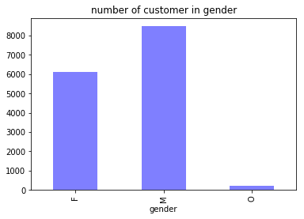

```python
profile.groupby('gender').size().plot(kind='bar', color='blue', alpha=0.5);
plt.title('number of customer in gender');
```

```python
# the number of customer for each gender
profile.groupby('gender').size()
```

```
gender
F    6129
M    8484
O     212
dtype: int64
```

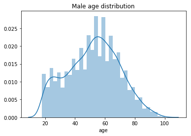

```python
sns.distplot(profile.query('gender == "M"')['age']);
plt.title('Male age distribution');
```

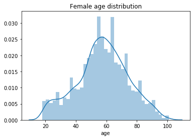

```python
sns.distplot(profile.query('gender == "F"')['age']);
plt.title('Female age distribution');
```

```python
# merge profile with transcript
result_profile = pd.merge(profile, transcript, left_on = 'id', right_on = 'person')
result_profile.head()
```

|  | age | became_member_on | gender | id | income | membership_year | event | person | time | value |
| --- | --- | --- | --- | --- | --- | --- | --- | --- | --- | --- |
| 0 | 55 | 2017-07-15 | F | 0610b486422d4921ae7d2bf64640c50b | 112000.0 | 2017 | transaction | 0610b486422d4921ae7d2bf64640c50b | 18 | {'amount': 21.51} |
| 1 | 55 | 2017-07-15 | F | 0610b486422d4921ae7d2bf64640c50b | 112000.0 | 2017 | transaction | 0610b486422d4921ae7d2bf64640c50b | 144 | {'amount': 32.28} |
| 2 | 55 | 2017-07-15 | F | 0610b486422d4921ae7d2bf64640c50b | 112000.0 | 2017 | offer received | 0610b486422d4921ae7d2bf64640c50b | 408 | {'offer id': '9b98b8c7a33c4b65b9aebfe6a799e6d9'} |
| 3 | 55 | 2017-07-15 | F | 0610b486422d4921ae7d2bf64640c50b | 112000.0 | 2017 | offer received | 0610b486422d4921ae7d2bf64640c50b | 504 | {'offer id': '3f207df678b143eea3cee63160fa8bed'} |
| 4 | 55 | 2017-07-15 | F | 0610b486422d4921ae7d2bf64640c50b | 112000.0 | 2017 | transaction | 0610b486422d4921ae7d2bf64640c50b | 528 | {'amount': 23.22} |

```python
value_df = pd.DataFrame()
value_df['person'] = result_profile.query('event == "offer completed"')['person']

# extract the amount of gained money from the offer
value_df['gained_money'] = result_profile.query('event == "offer completed"')['value'].apply(lambda x: x['reward'])
```

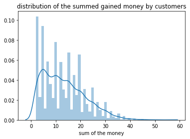

```python
# distribution of the amount of money consumed by each customer
sns.distplot(value_df.groupby('person')['gained_money'].sum());
plt.title('distribution of the summed gained money by customers');
plt.xlabel('sum of the money');
```

```python
# person id , gender, age
person_info = result_profile[['person', 'gender', 'age']].drop_duplicates()
```

```python
# merge with person_info
new_person_info = pd.merge(person_info, value_df, on='person')
new_person_info.head()
```

|  | person | gender | age | gained_money |
| --- | --- | --- | --- | --- |
| 0 | 0610b486422d4921ae7d2bf64640c50b | F | 55 | 5 |
| 1 | 78afa995795e4d85b5d9ceeca43f5fef | F | 75 | 5 |
| 2 | 78afa995795e4d85b5d9ceeca43f5fef | F | 75 | 10 |
| 3 | 78afa995795e4d85b5d9ceeca43f5fef | F | 75 | 5 |
| 4 | e2127556f4f64592b11af22de27a7932 | M | 68 | 5 |

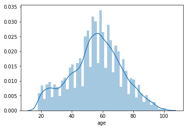

```python
# age distribution
sns.distplot(new_person_info['age']);
```

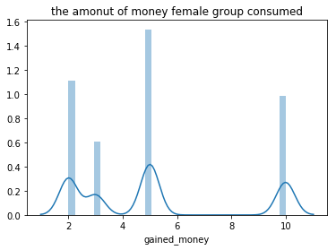

```python
# female group
sns.distplot(new_person_info.query('gender == "F"')['gained_money']);
plt.title('the amonut of money female group consumed');
```

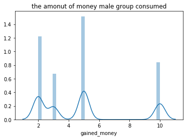

```python
# male group
sns.distplot(new_person_info.query('gender == "M"')['gained_money']);
plt.title('the amonut of money male group consumed');
```

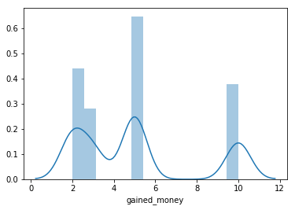

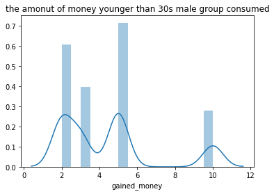

```python
# younger than 30s
for gender in ["F", "M"]:
    plt.figure()
    sns.distplot(new_person_info.query('gender == @gender and age < 30')['gained_money']);
    if gender == "F":
        gender = "female"
    else:
        gender = "male"
        plt.title('the amonut of money younger than 30s ' + gender + ' group consumed');
```

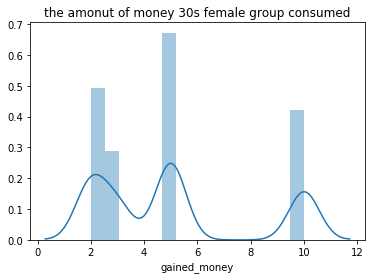

[figure not shown]

```python
# 30s
for gender in ["F", "M"]:
    plt.figure()
    sns.distplot(new_person_info.query('gender == @gender and age < 40 and age >= 30')['gained_money']);
    if gender == "F":
        gender = "female"
    else:
        gender = "male"

    plt.title('the amonut of money 30s ' + gender + ' group consumed');
```

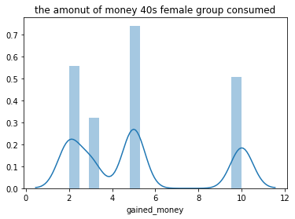

[figure not shown]

```python
# 40s
for gender in ["F", "M"]:
    plt.figure()
    sns.distplot(new_person_info.query('gender == @gender and age < 50 and age >= 40')['gained_money']);

    if gender == "F":
        gender = "female"
    else:
        gender = "male"

    plt.title('the amonut of money 40s ' + gender +' group consumed');
```

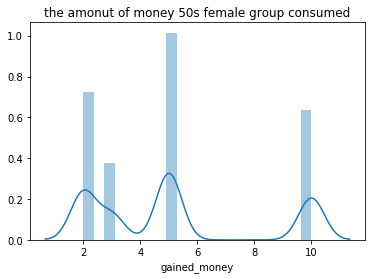

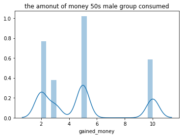

```python
# female and 50s
for gender in ["F", "M"]:
    plt.figure()
    sns.distplot(new_person_info.query('gender == @gender and age < 60 and age >= 50')['gained_money']);

    if gender == "F":
        gender = "female"
    else:
        gender = "male"
    plt.title('the amonut of money 50s ' + gender + ' group consumed');
```

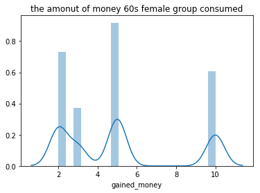

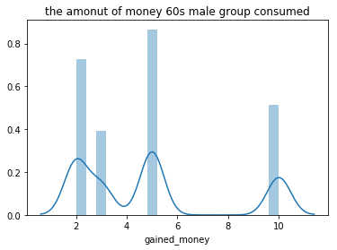

```python
# 60s
for gender in ["F", "M"]:
    plt.figure()
    sns.distplot(new_person_info.query('gender == @gender and age < 70 and age >= 60')['gained_money']);

    if gender == "F":
        gender = "female"
    else:
        gender = "male"

    plt.title('the amonut of money 60s ' + gender + ' group consumed');
```

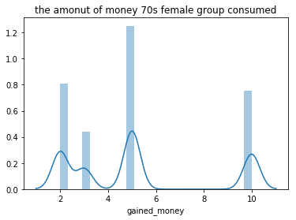

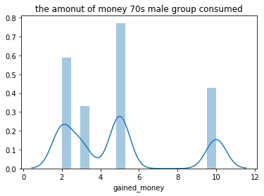

```python
# 70s
for gender in ["F", "M"]:
    plt.figure()
    sns.distplot(new_person_info.query('gender == @gender and age < 80 and age >= 70')['gained_money']);

    if gender == "F":
        gender = "female"
    else:
        gender = "male"

    plt.title('the amonut of money 70s ' + gender + ' group consumed');
```

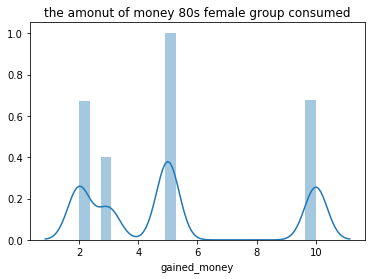

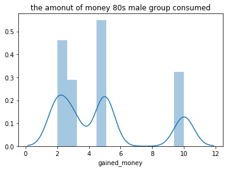

```python
# 80s
for gender in ["F", "M"]:
    plt.figure()
    sns.distplot(new_person_info.query('gender == @gender and age < 90 and age >= 80')['gained_money']);

    if gender == "F":
        gender = "female"
    else:
        gender = "male"

    plt.title('the amonut of money 80s ' + gender + ' group consumed');
```

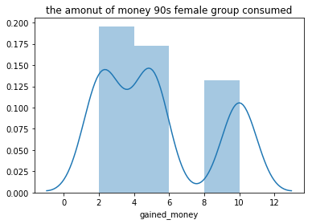

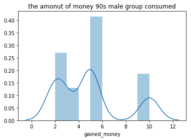

```python
# 90s
for gender in ["F", "M"]:
    plt.figure()
    sns.distplot(new_person_info.query('gender == @gender and age < 100 and age >= 90')['gained_money']);

    if gender == "F":
        gender = "female"
    else:
        gender = "male"

    plt.title('the amonut of money 90s ' + gender + ' group consumed');
```

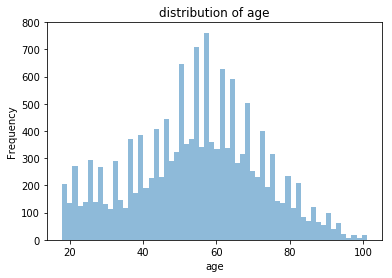

```python
# distibution of age
profile['age'].plot(kind='hist', bins=60, alpha=0.5);
plt.xlabel('age');
plt.title('distribution of age');
```

```python
profile[['age', 'income']].describe()
```

|  | age | income |
| --- | --- | --- |
| count | 14825.000000 | 14825.000000 |
| mean | 54.393524 | 65404.991568 |
| std | 17.383705 | 21598.299410 |
| min | 18.000000 | 30000.000000 |
| 25% | 42.000000 | 49000.000000 |
| 50% | 55.000000 | 64000.000000 |
| 75% | 66.000000 | 80000.000000 |
| max | 101.000000 | 120000.000000 |

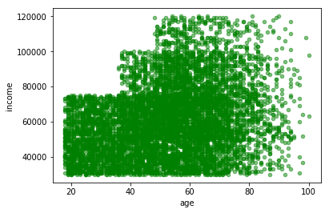

```python
# relationships betweem income, age, and gender
# check the data in terms of M, F, O
# Male
profile.query('gender == "M"')[['age', 'income']].plot(kind='scatter', x='age', y='income', color='green', alpha=0.5);
```

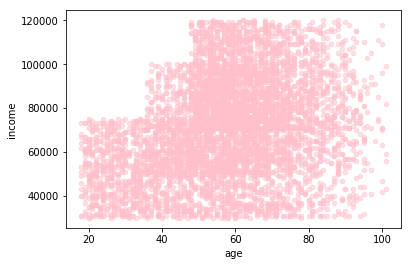

```python
# Female
profile.query('gender == "F"')[['age', 'income']].plot(kind='scatter', x='age', y='income', color='pink', alpha=0.5);
```

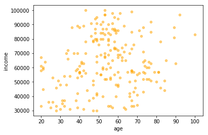

```python
# O
profile.query('gender == "O"')[['age', 'income']].plot(kind='scatter', x='age', y='income', color='orange', alpha=0.5);
```

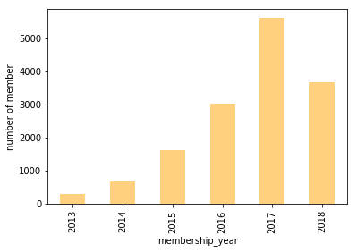

```python
# how many members joined at certain year
profile.groupby('membership_year').size().plot(kind='bar', color='orange', alpha=0.5);
plt.ylabel('number of member');
```

```python
result_profile.head()
```

|  | age | became_member_on | gender | id | income | membership_year | event | person | time | value |
| --- | --- | --- | --- | --- | --- | --- | --- | --- | --- | --- |
| 0 | 55 | 2017-07-15 | F | 0610b486422d4921ae7d2bf64640c50b | 112000.0 | 2017 | transaction | 0610b486422d4921ae7d2bf64640c50b | 18 | {'amount': 21.51} |
| 1 | 55 | 2017-07-15 | F | 0610b486422d4921ae7d2bf64640c50b | 112000.0 | 2017 | transaction | 0610b486422d4921ae7d2bf64640c50b | 144 | {'amount': 32.28} |
| 2 | 55 | 2017-07-15 | F | 0610b486422d4921ae7d2bf64640c50b | 112000.0 | 2017 | offer received | 0610b486422d4921ae7d2bf64640c50b | 408 | {'offer id': '9b98b8c7a33c4b65b9aebfe6a799e6d9'} |
| 3 | 55 | 2017-07-15 | F | 0610b486422d4921ae7d2bf64640c50b | 112000.0 | 2017 | offer received | 0610b486422d4921ae7d2bf64640c50b | 504 | {'offer id': '3f207df678b143eea3cee63160fa8bed'} |
| 4 | 55 | 2017-07-15 | F | 0610b486422d4921ae7d2bf64640c50b | 112000.0 | 2017 | transaction | 0610b486422d4921ae7d2bf64640c50b | 528 | {'amount': 23.22} |

```python
# what kind of customer who has the longer membership
for gender in ['M', 'F', 'O']:
    print('gender is ', gender)
    earliest_time = profile[['age', 'became_member_on', 'gender', 'income']].query('gender == @gender')['became_member_on'].min()
    print('the earliest time to become a member is ', earliest_time)

    age = profile[['age', 'became_member_on', 'gender', 'income']].query('gender == @gender & became_member_on == @earliest_time')['age']
    income = profile[['age', 'became_member_on', 'gender', 'income']].query('gender == @gender & became_member_on == @earliest_time')['income']

    print('age is', age.values[0], 'and income is ', income.values[0])
    print()
```

```
gender is  M
the earliest time to become a member is  2013-07-29 00:00:00
age is 64 and income is  69000.0

gender is  F
the earliest time to become a member is  2013-07-30 00:00:00
age is 58 and income is  55000.0

gender is  O
the earliest time to become a member is  2013-09-19 00:00:00
age is 40 and income is  56000.0
```

```python
# sort by difficulty
portfolio.sort_values(by='difficulty')[portfolio.columns[~portfolio.columns.isin(['id'])]]
```

|  | channels | difficulty | duration | offer_type | reward | web | email | social | mobile | bogo | informational | discount |
| --- | --- | --- | --- | --- | --- | --- | --- | --- | --- | --- | --- | --- |
| 2 | [web, email, mobile] | 0 | 4 | informational | 0 | 1.0 | 1.0 | 0.0 | 1.0 | 0.0 | 1.0 | 0.0 |
| 7 | [email, mobile, social] | 0 | 3 | informational | 0 | 0.0 | 1.0 | 1.0 | 1.0 | 0.0 | 1.0 | 0.0 |
| 3 | [web, email, mobile] | 5 | 7 | bogo | 5 | 1.0 | 1.0 | 0.0 | 1.0 | 1.0 | 0.0 | 0.0 |
| 8 | [web, email, mobile, social] | 5 | 5 | bogo | 5 | 1.0 | 1.0 | 1.0 | 1.0 | 1.0 | 0.0 | 0.0 |
| 5 | [web, email, mobile, social] | 7 | 7 | discount | 3 | 1.0 | 1.0 | 1.0 | 1.0 | 0.0 | 0.0 | 1.0 |
| 0 | [email, mobile, social] | 10 | 7 | bogo | 10 | 0.0 | 1.0 | 1.0 | 1.0 | 1.0 | 0.0 | 0.0 |
| 1 | [web, email, mobile, social] | 10 | 5 | bogo | 10 | 1.0 | 1.0 | 1.0 | 1.0 | 1.0 | 0.0 | 0.0 |
| 6 | [web, email, mobile, social] | 10 | 10 | discount | 2 | 1.0 | 1.0 | 1.0 | 1.0 | 0.0 | 0.0 | 1.0 |
| 9 | [web, email, mobile] | 10 | 7 | discount | 2 | 1.0 | 1.0 | 0.0 | 1.0 | 0.0 | 0.0 | 1.0 |
| 4 | [web, email] | 20 | 10 | discount | 5 | 1.0 | 1.0 | 0.0 | 0.0 | 0.0 | 0.0 | 1.0 |

```python
# sort by reward
portfolio.sort_values(by='reward')[portfolio.columns[~portfolio.columns.isin(['id'])]]
```

|  | channels | difficulty | duration | offer_type | reward | web | email | social | mobile | bogo | informational | discount |
| --- | --- | --- | --- | --- | --- | --- | --- | --- | --- | --- | --- | --- |
| 2 | [web, email, mobile] | 0 | 4 | informational | 0 | 1.0 | 1.0 | 0.0 | 1.0 | 0.0 | 1.0 | 0.0 |
| 7 | [email, mobile, social] | 0 | 3 | informational | 0 | 0.0 | 1.0 | 1.0 | 1.0 | 0.0 | 1.0 | 0.0 |
| 6 | [web, email, mobile, social] | 10 | 10 | discount | 2 | 1.0 | 1.0 | 1.0 | 1.0 | 0.0 | 0.0 | 1.0 |
| 9 | [web, email, mobile] | 10 | 7 | discount | 2 | 1.0 | 1.0 | 0.0 | 1.0 | 0.0 | 0.0 | 1.0 |
| 5 | [web, email, mobile, social] | 7 | 7 | discount | 3 | 1.0 | 1.0 | 1.0 | 1.0 | 0.0 | 0.0 | 1.0 |
| 3 | [web, email, mobile] | 5 | 7 | bogo | 5 | 1.0 | 1.0 | 0.0 | 1.0 | 1.0 | 0.0 | 0.0 |
| 4 | [web, email] | 20 | 10 | discount | 5 | 1.0 | 1.0 | 0.0 | 0.0 | 0.0 | 0.0 | 1.0 |
| 8 | [web, email, mobile, social] | 5 | 5 | bogo | 5 | 1.0 | 1.0 | 1.0 | 1.0 | 1.0 | 0.0 | 0.0 |
| 0 | [email, mobile, social] | 10 | 7 | bogo | 10 | 0.0 | 1.0 | 1.0 | 1.0 | 1.0 | 0.0 | 0.0 |
| 1 | [web, email, mobile, social] | 10 | 5 | bogo | 10 | 1.0 | 1.0 | 1.0 | 1.0 | 1.0 | 0.0 | 0.0 |

```python
# pick up only numeric data
targets = ['difficulty', 'duration', 'reward']
portfolio_corr = portfolio[targets].corr()
```

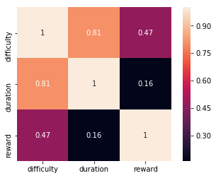

```python
# correlation betwene reward, duration and difficulty
sns.heatmap(portfolio_corr, square=True, annot=True);
```

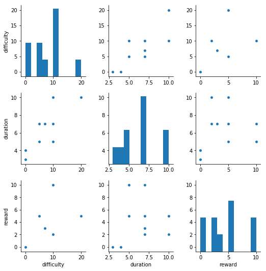

```python
# plot of the relation
sns.pairplot(portfolio[targets]);
# if difficulty is increased, the duration tends to increase
```

#### Correlation

- It looks `difficulty` and `duration` relate more than others.
- When `difficulty` is increased, `duration` tends to be longer.

```python
portfolio.groupby(['difficulty', 'duration']).size()
```

```
difficulty  duration
0           3           1
            4           1
5           5           1
            7           1
7           7           1
10          5           1
            7           2
            10          1
20          10          1
dtype: int64
```

# what kind customers can get certain kinds offer?

```python
portfolio['difficulty'].unique() # the variation of `difficulty`
```

```
array([10,  0,  5, 20,  7])
```

```python
portfolio['offer_type'].unique()
```

```
array(['bogo', 'informational', 'discount'], dtype=object)
```

## bogo group

- buy-one-get-one
- a user needs to spend a certain amount to get a reward equal to that threshold amount.

```python
# For bogo group
bogo_gr = portfolio.query('offer_type == "bogo"')
bogo_gr
```

|  | channels | difficulty | duration | id | offer_type | reward | web | email | social | mobile | bogo | informational | discount |
| --- | --- | --- | --- | --- | --- | --- | --- | --- | --- | --- | --- | --- | --- |
| 0 | [email, mobile, social] | 10 | 7 | ae264e3637204a6fb9bb56bc8210ddfd | bogo | 10 | 0.0 | 1.0 | 1.0 | 1.0 | 1.0 | 0.0 | 0.0 |
| 1 | [web, email, mobile, social] | 10 | 5 | 4d5c57ea9a6940dd891ad53e9dbe8da0 | bogo | 10 | 1.0 | 1.0 | 1.0 | 1.0 | 1.0 | 0.0 | 0.0 |
| 3 | [web, email, mobile] | 5 | 7 | 9b98b8c7a33c4b65b9aebfe6a799e6d9 | bogo | 5 | 1.0 | 1.0 | 0.0 | 1.0 | 1.0 | 0.0 | 0.0 |
| 8 | [web, email, mobile, social] | 5 | 5 | f19421c1d4aa40978ebb69ca19b0e20d | bogo | 5 | 1.0 | 1.0 | 1.0 | 1.0 | 1.0 | 0.0 | 0.0 |

```python
bogo_gr['difficulty'].unique() # bogo group has 10 or 5 difficulty
```

```
array([10,  5])
```

```python
channels = ['web', 'email', 'social', 'mobile']
bogo_gr[channels].sum() # most customers have all channel
```

```
web       3.0
email     4.0
social    3.0
mobile    4.0
dtype: float64
```

```python
# how about the duration (time for offer to be open, in days)
bogo_gr['duration'].unique()
```

```
array([7, 5])
```

```python
bogo_gr['duration'].median() # median is 6 days
```

```
6.0
```

## informational group

- there is no reward, but neither is there a requisite amount that the user is expected to spend

```python
# informational group
info_gr = portfolio.query('offer_type == "informational"')
info_gr
```

|  | channels | difficulty | duration | id | offer_type | reward | web | email | social | mobile | bogo | informational | discount |
| --- | --- | --- | --- | --- | --- | --- | --- | --- | --- | --- | --- | --- | --- |
| 2 | [web, email, mobile] | 0 | 4 | 3f207df678b143eea3cee63160fa8bed | informational | 0 | 1.0 | 1.0 | 0.0 | 1.0 | 0.0 | 1.0 | 0.0 |
| 7 | [email, mobile, social] | 0 | 3 | 5a8bc65990b245e5a138643cd4eb9837 | informational | 0 | 0.0 | 1.0 | 1.0 | 1.0 | 0.0 | 1.0 | 0.0 |

```python
info_gr['difficulty'].unique() # difficulty and reward is 0
# which means you don't need to spend much money to get informational offer
```

```
array([0])
```

```python
info_gr[channels].sum() # web and social are lower
# they tend to have just email and mobile
```

```
web       1.0
email     2.0
social    1.0
mobile    2.0
dtype: float64
```

```python
# how many days to take to be opened
info_gr['duration'].unique()
```

```
array([4, 3])
```

```python
info_gr['duration'].median() # median is 3.5 days
```

```
3.5
```

## discount group

- a user gains a reward equal to a fraction of the amount spent.

```python
disc_gr = portfolio.query('offer_type == "discount"')
disc_gr
```

|  | channels | difficulty | duration | id | offer_type | reward | web | email | social | mobile | bogo | informational | discount |
| --- | --- | --- | --- | --- | --- | --- | --- | --- | --- | --- | --- | --- | --- |
| 4 | [web, email] | 20 | 10 | 0b1e1539f2cc45b7b9fa7c272da2e1d7 | discount | 5 | 1.0 | 1.0 | 0.0 | 0.0 | 0.0 | 0.0 | 1.0 |
| 5 | [web, email, mobile, social] | 7 | 7 | 2298d6c36e964ae4a3e7e9706d1fb8c2 | discount | 3 | 1.0 | 1.0 | 1.0 | 1.0 | 0.0 | 0.0 | 1.0 |
| 6 | [web, email, mobile, social] | 10 | 10 | fafdcd668e3743c1bb461111dcafc2a4 | discount | 2 | 1.0 | 1.0 | 1.0 | 1.0 | 0.0 | 0.0 | 1.0 |
| 9 | [web, email, mobile] | 10 | 7 | 2906b810c7d4411798c6938adc9daaa5 | discount | 2 | 1.0 | 1.0 | 0.0 | 1.0 | 0.0 | 0.0 | 1.0 |

**Even `difficulty` is highest, 20, the reward for those customer is just `5`.**

```python
disc_gr[channels].sum() # all has web and email
```

```
web       4.0
email     4.0
social    2.0
mobile    3.0
dtype: float64
```

```python
# how about separating data in terms of `difficulty`?
for difficulty in portfolio['difficulty'].unique():
    print('---')
    print('difficulty is ', difficulty)
    display(portfolio.query('difficulty == @difficulty')[['duration', 'offer_type']])
```

```
---
difficulty is  10
```

|  | duration | offer_type |
| --- | --- | --- |
| 0 | 7 | bogo |
| 1 | 5 | bogo |
| 6 | 10 | discount |
| 9 | 7 | discount |

```
---
difficulty is  0
```

|  | duration | offer_type |
| --- | --- | --- |
| 2 | 4 | informational |
| 7 | 3 | informational |

```
---
difficulty is  5
```

|  | duration | offer_type |
| --- | --- | --- |
| 3 | 7 | bogo |
| 8 | 5 | bogo |

```
---
difficulty is  20
```

|  | duration | offer_type |
| --- | --- | --- |
| 4 | 10 | discount |

```
---
difficulty is  7
```

|  | duration | offer_type |
| --- | --- | --- |
| 5 | 7 | discount |

```python
# check the relationship between offers, difficulty(the amonut of money they spent) and duration
portfolio[['difficulty', 'bogo', 'informational', 'discount', 'duration']]
```

|  | difficulty | bogo | informational | discount | duration |
| --- | --- | --- | --- | --- | --- |
| 0 | 10 | 1.0 | 0.0 | 0.0 | 7 |
| 1 | 10 | 1.0 | 0.0 | 0.0 | 5 |
| 2 | 0 | 0.0 | 1.0 | 0.0 | 4 |
| 3 | 5 | 1.0 | 0.0 | 0.0 | 7 |
| 4 | 20 | 0.0 | 0.0 | 1.0 | 10 |
| 5 | 7 | 0.0 | 0.0 | 1.0 | 7 |
| 6 | 10 | 0.0 | 0.0 | 1.0 | 10 |
| 7 | 0 | 0.0 | 1.0 | 0.0 | 3 |
| 8 | 5 | 1.0 | 0.0 | 0.0 | 5 |
| 9 | 10 | 0.0 | 0.0 | 1.0 | 7 |

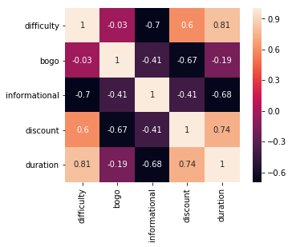

```python
sns.heatmap(portfolio[['difficulty', 'bogo', 'informational', 'discount', 'duration']].corr(),
            square=True, annot=True);
```

# What I think....

```python
result_profile.groupby('id').size()
```

```
id
0009655768c64bdeb2e877511632db8f    20
0011e0d4e6b944f998e987f904e8c1e5    18
0020c2b971eb4e9188eac86d93036a77    19
0020ccbbb6d84e358d3414a3ff76cffd    23
003d66b6608740288d6cc97a6903f4f0    30
00426fe3ffde4c6b9cb9ad6d077a13ea    25
004b041fbfe44859945daa2c7f79ee64    13
004c5799adbf42868b9cff0396190900    26
005500a7188546ff8a767329a2f7c76a    13
0056df74b63b4298809f0b375a304cf4    15
00715b6e55c3431cb56ff7307eb19675    29
0082fd87c18f45f2be70dbcbb0fb8aad    18
00840a2ca5d2408e982d56544dc14ffd    28
00857b24b13f4fe0ad17b605f00357f5    12
008d7088107b468893889da0ede0df5c    18
0091d2b6a5ea4defaa8393e4e816db60    26
0099bf30e4cb4265875266eb3eb25eab    19
00a794f62b9a48beb58f8f6c02c2f1a6    22
00ae03011f9f49b8a4b3e6d416678b0b    23
00aee28bbb3848dd8a31f0c91dc267dd    10
00b18b535d6d4f779dea4dc9ac451478    18
00b3400e4ff64ee68ce9ada1d0c222f0    20
00b3c376db2a4115af3aef34a02f61d6    16
00b901d68f8f4fd68075184cd0f772d2    12
00bbce6533f44ddeaf4dd32bcab55441    18
00bc42a62f884b41a13cc595856cf7c3    22
00bc983061d3471e8c8e74d31b7c8b6f    10
00c20a9202d5475190b31a24de6fb06d    20
00c2f812f4604c8893152a5c6572030e    17
00c32a104f0c4065b5b552895fb22e34     9
                                    ..
ff8bee9ba3754ac687d9af685b2981b7     6
ff8ff8e5d8bb449894bf708924020edc    22
ff932c6f8bb641bd816955337d153676    29
ff95e0a9cdfd4030958762dadcb11e1a    11
ff992fbec53145bbae59a68d025e0458    40
ff9beda564da4bab81633fca744037dc    18
ff9f73ead16a4f9b9e1a53a27280af92    26
ffa81afacde642a3a51a7cd99f8d2cd7    21
```

[output cut: 8 more lines]

```
ffd53e5ba61d41378b66efc00d9f9682    24
ffd810f301ad42d6bfe98c4ba6ee4125     6
ffda4545e7084ff6aaf01304fb1c1fa6    12
ffdefcac307f4ca99ac1ebd51470f106    20
ffe5257abf8840b395e1ee6b29894637    14
ffeaa02452ef451082a0361c3ca62ef5    25
ffed75d3abc64b488982f50ed12878b5     4
fff0f0aac6c547b9b263080f09a5586a    12
fff29fb549084123bd046dbc5ceb4faa    28
fff3ba4757bd42088c044ca26d73817a    23
fff7576017104bcc8677a8d63322b5e1    18
fff8957ea8b240a6b5e634b6ee8eafcf    10
fffad4f4828548d1b5583907f2e9906b    23
ffff82501cea40309d5fdd7edcca4a07    33
Length: 14825, dtype: int64
```

```python
result_profile['event'].unique()
```

```
array(['transaction', 'offer received', 'offer completed', 'offer viewed'], dtype=object)
```

**How many times do they get the offers?**

```python
# how many times do they get the offers?
result_profile.groupby('id').size().mean() # about 18 times
```

```
18.398785834738618
```

```python
# you can check the substract of time between `offer received` and other event
```

```
offer viewed and  F
mean  57.5424847385
min  18
max  101
offer viewed and  M
mean  52.1091276925
min  18
max  100
transaction and  F
mean  57.4722175872
min  18
max  101
transaction and  M
mean  52.0189270645
min  18
max  100
offer received and  F
mean  57.5422040816
min  18
max  101
offer received and  M
mean  52.1121065661
min  18
max  100
offer completed and  F
mean  57.904099425
min  18
max  101
offer completed and  M
mean  53.0045199501
min  18
max  100
```

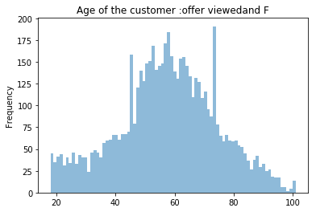

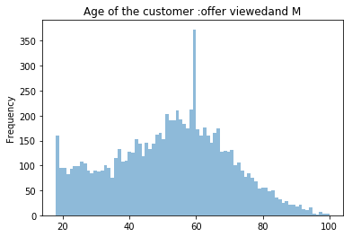

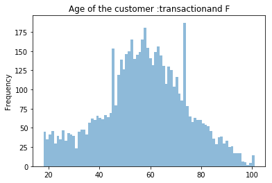

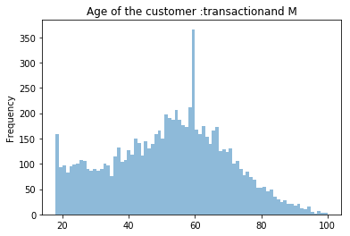

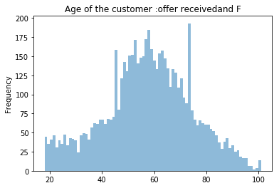

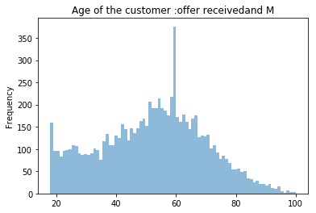

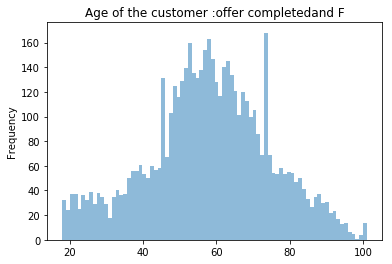

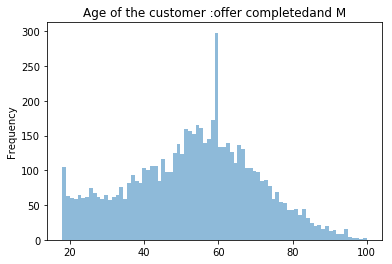

```python
for kind in ['offer viewed', 'transaction', 'offer received', 'offer completed']:
    tmp = result_profile.query('event == @kind')

    for gender in ['F', 'M']:
        plt.figure()

        # drop duplicated id for distribution of age
        dr_tmp = tmp.query('gender == @gender').drop_duplicates(subset='id')

        dr_tmp['age'].plot(kind='hist', bins=80, alpha=0.5);
        plt.title('Age of the customer :'+ kind +'and ' + gender);
        print(kind, 'and ', gender)
        print('mean ', dr_tmp['age'].mean())
        print('min ', dr_tmp['age'].min())
        print('max ', dr_tmp['age'].max())
```

```python
# how about th ratio
for kind in ['offer viewed', 'transaction', 'offer received', 'offer completed']:
    tmp = result_profile.query('event == @kind')

    for gender in ['F', 'M']:

        # drop duplicated id for distribution of age
        dr_tmp = tmp.query('gender == @gender').drop_duplicates(subset='id')

        denominator = len(result_profile.query('gender == @gender').drop_duplicates(subset='id'))
        numerator = len(dr_tmp)

        print(kind, ' : ', gender)
        print((numerator * 100 / denominator), '%')
        print()

# result
# offer completed : male is lower than female (Female : Male = 88% : 76%)
# other kind of event doesn't have a big difference in gender
```

```
offer viewed  :  F
98.89052047642356 %

offer viewed  :  M
99.04526166902404 %

transaction  :  F
97.78104095284712 %

transaction  :  M
97.77227722772277 %

offer received  :  F
99.93473649861315 %

offer received  :  M
99.98821310702499 %

offer completed  :  F
87.95888399412628 %

offer completed  :  M
75.62470532767563 %
```

```python
# how much money was spent with the offier?
transaction_df = result_profile.query('event == "transaction"')
transaction_df['value'].head()
```

```
0     {'amount': 21.51}
1     {'amount': 32.28}
4     {'amount': 23.22}
8     {'amount': 19.89}
10    {'amount': 17.78}
Name: value, dtype: object
```

```python
# make a column for the amonut of money in the purchase
transaction_df['amount'] = transaction_df['value'].apply(lambda x: list(x.values())[0])
```

```python
transaction_df.head()
```

|  | age | became_member_on | gender | id | income | membership_year | event | person | time | value | amount |
| --- | --- | --- | --- | --- | --- | --- | --- | --- | --- | --- | --- |
| 0 | 55 | 2017-07-15 | F | 0610b486422d4921ae7d2bf64640c50b | 112000.0 | 2017 | transaction | 0610b486422d4921ae7d2bf64640c50b | 18 | {'amount': 21.51} | 21.51 |
| 1 | 55 | 2017-07-15 | F | 0610b486422d4921ae7d2bf64640c50b | 112000.0 | 2017 | transaction | 0610b486422d4921ae7d2bf64640c50b | 144 | {'amount': 32.28} | 32.28 |
| 4 | 55 | 2017-07-15 | F | 0610b486422d4921ae7d2bf64640c50b | 112000.0 | 2017 | transaction | 0610b486422d4921ae7d2bf64640c50b | 528 | {'amount': 23.22} | 23.22 |
| 8 | 75 | 2017-05-09 | F | 78afa995795e4d85b5d9ceeca43f5fef | 100000.0 | 2017 | transaction | 78afa995795e4d85b5d9ceeca43f5fef | 132 | {'amount': 19.89} | 19.89 |
| 10 | 75 | 2017-05-09 | F | 78afa995795e4d85b5d9ceeca43f5fef | 100000.0 | 2017 | transaction | 78afa995795e4d85b5d9ceeca43f5fef | 144 | {'amount': 17.78} | 17.78 |

```python
transaction_df.groupby('id')['amount'].sum().sort_values(ascending=False) # 14492 unique customer
```

```
id
3c8d541112a74af99e88abbd0692f00e    1608.69
f1d65ae63f174b8f80fa063adcaa63b7    1365.66
ae6f43089b674728a50b8727252d3305    1327.74
626df8678e2a4953b9098246418c9cfa    1321.42
73afdeca19e349b98f09e928644610f8    1319.97
52959f19113e4241a8cb3bef486c6412    1292.86
ad1f0a409ae642bc9a43f31f56c130fc    1258.19
d240308de0ee4cf8bb6072816268582b    1251.99
946fc0d3ecc4492aa4cc06cf6b1492c3    1232.40
6406abad8e2c4b8584e4f68003de148d    1211.76
6cf884a6c5ae4b2daccb6d3108028fef    1165.26
8c6b2a81cb294c28b740e9c459ab7767    1154.75
5ecaea5c8bf44ae4a65838d9d066c909    1153.11
4d0ebb94a5a94fe6afd9350c7b1477e4    1152.94
dce784e26f294101999d000fad9089bb    1151.86
05bedc6bbcc64a41b1745f6efe00776d    1148.92
a73cf044395d46ea804f688490ad9227    1128.22
ca715b3f17e24692b18f3cd90b9bf232    1118.78
c7a5d7bab83a4d82a7f977b3d586f3d4    1118.73
5dfdad4241764dfe959f51b7460e42b1    1112.66
7d7f271652d244f78b97c73cd734c553    1106.17
1c05e4a68fc04d3da27454cb7eaa6144    1099.28
454b00bdd77c4f588eb9f6cafd81dc5d    1087.98
e7f53eb7aba343e09c8975e998cdf0a6    1087.24
0a3c4a0c066d49f1ad4eb52987a0fb05    1084.84
ca3ed3e47a1e4ceea8dcd8b2bbaf1076    1080.21
f4e953ec3a484683935d8d42216fd11e    1080.07
c0bbc13872474c63a83e8b503bb88f72    1075.80
b923ef146c9d48518edc006f611f0f5c    1074.65
cd10ba15be244a36a61dc4256e7d6f6b    1069.53
                                     ...
8d2f8960fd8c42c8abc94bd6f5056118       1.11
1f9e0510404c44a38d0d826f8f9e1dfc       1.10
0e79ee043ba442189e07d907c5590c98       1.04
9fddb6531bea44d0919eabfd13865924       1.03
66897badf9c641d1925af5fdbefe1308       1.01
2b7c18169e88411596f4231ccda5d15b       0.97
1daa1946d8ba40c7b6502bc679426f13       0.95
8c93308bc4a243ba83f8294407894d69       0.91
```

[output cut: 8 more lines]

```
0b265c689a2b406095d5aec5b33bded9       0.67
0934678d34c54056b8fb1203d8bad8ab       0.63
02db8af535e54416a01aff51836d166f       0.61
86b32116a2364361a0c6fb793194887b       0.54
a2a0e12b976846bdacf3d29d74b5bf35       0.48
c3f3b8193c8a4133b8bd0654f82654a1       0.47
10b82c47a87a403abe13dde32c5af8fc       0.45
e6ac047d133f4cc7b159d757bf3e0a0d       0.41
3bfb6c8c7d8d42e68c9f66d296a1c96b       0.33
0d3451dbd862480caf1f408154c18887       0.29
74565e746984484d9600d596980fda12       0.28
49c4a0965ad04077bac189d20a88ec4e       0.23
ca5815021d3c42e2bef68f023a7764d0       0.17
b90505ef4a754b139d54db583ee424ac       0.15
Name: amount, Length: 14492, dtype: float64
```

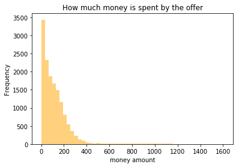

```python
transaction_df.groupby('id')['amount'].sum().sort_values(ascending=False).plot(kind='hist', color='orange',
                                                                              alpha=0.5, bins=50);
plt.xlabel('money amount');
plt.title('How much money is spent by the offer');
```

```python
# mean and median in all
print('mean ', transaction_df.groupby('id')['amount'].sum().mean())
print('median ', transaction_df.groupby('id')['amount'].sum().median())
```

```
mean  119.717250897
median  89.86
```

```python
# mean and median in each customer
print('mean ', transaction_df.groupby('id')['amount'].mean())
print('median ', transaction_df.groupby('id')['amount'].median())
```

```
mean  id
0009655768c64bdeb2e877511632db8f    15.950000
0011e0d4e6b944f998e987f904e8c1e5    15.892000
0020c2b971eb4e9188eac86d93036a77    24.607500
0020ccbbb6d84e358d3414a3ff76cffd    12.837500
003d66b6608740288d6cc97a6903f4f0     2.685556
00426fe3ffde4c6b9cb9ad6d077a13ea     4.030000
004b041fbfe44859945daa2c7f79ee64    23.060000
004c5799adbf42868b9cff0396190900    28.948333
005500a7188546ff8a767329a2f7c76a     5.090000
0056df74b63b4298809f0b375a304cf4    28.828000
00715b6e55c3431cb56ff7307eb19675    25.008000
0082fd87c18f45f2be70dbcbb0fb8aad    17.407143
00840a2ca5d2408e982d56544dc14ffd     3.701765
00857b24b13f4fe0ad17b605f00357f5     1.565000
008d7088107b468893889da0ede0df5c     2.311429
0091d2b6a5ea4defaa8393e4e816db60    23.263333
0099bf30e4cb4265875266eb3eb25eab    11.758889
00a794f62b9a48beb58f8f6c02c2f1a6    15.127273
00ae03011f9f49b8a4b3e6d416678b0b    27.256250
00aee28bbb3848dd8a31f0c91dc267dd     4.106000
00b18b535d6d4f779dea4dc9ac451478    26.650000
00b3400e4ff64ee68ce9ada1d0c222f0    16.392000
00b3c376db2a4115af3aef34a02f61d6    27.453750
00b901d68f8f4fd68075184cd0f772d2    13.387500
00bbce6533f44ddeaf4dd32bcab55441    11.030000
00bc42a62f884b41a13cc595856cf7c3    18.830000
00bc983061d3471e8c8e74d31b7c8b6f    21.166667
00c20a9202d5475190b31a24de6fb06d    20.501250
00c2f812f4604c8893152a5c6572030e    24.818000
00c32a104f0c4065b5b552895fb22e34     3.490000
                                      ...
ff7cc9b97c7744cfbc31bb020ea8d07e     7.865455
ff7fdf82996949ec82d158a02a1d9cca    15.002941
ff80a43ecb34439491bd9ae1cff7c5fc     4.226667
ff8b6918b14448dd8a80d0dc8154f2a0    24.674286
ff8ff8e5d8bb449894bf708924020edc    12.092500
ff932c6f8bb641bd816955337d153676    22.681818
ff95e0a9cdfd4030958762dadcb11e1a    20.076667
ff992fbec53145bbae59a68d025e0458     3.079583
```

[output cut: 71 more lines]

```
ffc77312ccda49fca19506f1cdf44923     3.320
ffc8a38e0972421785b00f80c92c8085    31.660
ffd53e5ba61d41378b66efc00d9f9682     6.205
ffda4545e7084ff6aaf01304fb1c1fa6    21.880
ffdefcac307f4ca99ac1ebd51470f106    11.835
ffe5257abf8840b395e1ee6b29894637    15.220
ffeaa02452ef451082a0361c3ca62ef5    19.995
fff0f0aac6c547b9b263080f09a5586a    18.770
fff29fb549084123bd046dbc5ceb4faa    25.850
fff3ba4757bd42088c044ca26d73817a    20.980
fff7576017104bcc8677a8d63322b5e1     5.030
fff8957ea8b240a6b5e634b6ee8eafcf     0.890
fffad4f4828548d1b5583907f2e9906b     7.515
ffff82501cea40309d5fdd7edcca4a07    15.570
Name: amount, Length: 14492, dtype: float64
```

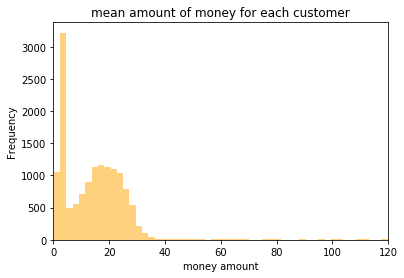

```python
transaction_df.groupby('id')['amount'].mean().plot(kind='hist', color='orange',
                                                  bins=200, alpha=0.5);
plt.xlim(0,120);
plt.title('mean amount of money for each customer')
plt.xlabel('money amount');
```

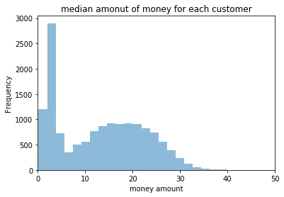

```python
transaction_df.groupby('id')['amount'].median().plot(kind='hist', bins=250,
                                                    alpha=0.5);
plt.xlim(0,50);
plt.title('median amonut of money for each customer');
plt.xlabel('money amount');
```

```python
# min
transaction_df.groupby('id')['amount'].median().min()
# min of median amount of money is about 0.15
```

```
0.14999999999999999
```

```python
# extract customer who spent more than 0.15 in a purchase
medi_customer = transaction_df[transaction_df['amount'] >= 0.15]
```

```python
# data of unique customer in medi_customer
customer_features = medi_customer[['age', 'gender', 'id', 'income','membership_year']].drop_duplicates()
```

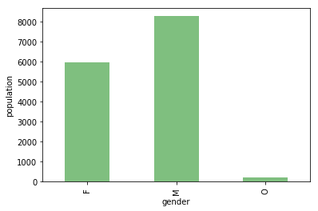

```python
# composition in gender
customer_features.groupby('gender').size().plot(kind='bar', color='green', alpha=0.5);
plt.ylabel('population');
# men is lager portion
```

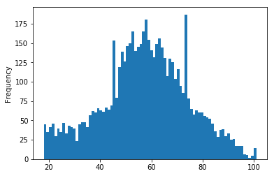

```python
# composition in age
# female
customer_features.query('gender == "F"')['age'].plot(kind='hist', bins=80);
# middle age group is bigger
```

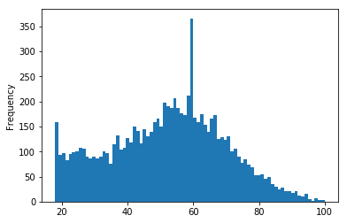

```python
# male
customer_features.query('gender == "M"')['age'].plot(kind='hist', bins=80);
# younger age (from 10s~30s) is bigger than in female data
```

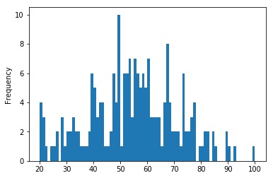

```python
# O
customer_features.query('gender == "O"')['age'].plot(kind='hist', bins=80);
```

```python
# median income in female
customer_features.query('gender == "F"')['income'].median() # 71000
```

```
71000.0
```

```python
# mean income in female
customer_features.query('gender == "F"')['income'].mean() # about 71132
```

```
71132.154179876525
```

```python
# median income in male
customer_features.query('gender == "M"')['income'].median() # 59000
```

```
59000.0
```

```python
# mean income in male
customer_features.query('gender == "M"')['income'].mean() # about 61001
```

```
61001.928872814948
```

## Results of analysis for a group from the perspective of age, gender and income

male's income tends to be lower than female.  
This might cause more yonger male customers make purchase with the offer.

```python
# focus on younger male group
# how much money did they spent?
# get their id
younger_male_id = customer_features.query('gender == "M" and age < 40')['id']
```

```python
# extract data with younger_male_id
younger_male_df = transaction_df[transaction_df['id'].isin(younger_male_id)]
```

```python
# top 10 for the sum of the money they spent by one younger male customer
top10_sum_id = younger_male_df.groupby('id')['amount'].sum().sort_values(ascending=False)[0:10] # top 10
```

```python
younger_male_df[younger_male_df['id'] == top10_sum_id.index[0]]
# he spent more money with the offers
# income 64000
# age 32
# membership year 2018
```

|  | age | became_member_on | gender | id | income | membership_year | event | person | time | value | amount |
| --- | --- | --- | --- | --- | --- | --- | --- | --- | --- | --- | --- |
| 216495 | 32 | 2018-06-19 | M | f1d65ae63f174b8f80fa063adcaa63b7 | 64000.0 | 2018 | transaction | f1d65ae63f174b8f80fa063adcaa63b7 | 12 | {'amount': 639.59} | 639.59 |
| 216497 | 32 | 2018-06-19 | M | f1d65ae63f174b8f80fa063adcaa63b7 | 64000.0 | 2018 | transaction | f1d65ae63f174b8f80fa063adcaa63b7 | 30 | {'amount': 11.51} | 11.51 |
| 216498 | 32 | 2018-06-19 | M | f1d65ae63f174b8f80fa063adcaa63b7 | 64000.0 | 2018 | transaction | f1d65ae63f174b8f80fa063adcaa63b7 | 138 | {'amount': 18.79} | 18.79 |
| 216500 | 32 | 2018-06-19 | M | f1d65ae63f174b8f80fa063adcaa63b7 | 64000.0 | 2018 | transaction | f1d65ae63f174b8f80fa063adcaa63b7 | 192 | {'amount': 13.23} | 13.23 |
| 216502 | 32 | 2018-06-19 | M | f1d65ae63f174b8f80fa063adcaa63b7 | 64000.0 | 2018 | transaction | f1d65ae63f174b8f80fa063adcaa63b7 | 288 | {'amount': 12.12} | 12.12 |
| 216506 | 32 | 2018-06-19 | M | f1d65ae63f174b8f80fa063adcaa63b7 | 64000.0 | 2018 | transaction | f1d65ae63f174b8f80fa063adcaa63b7 | 372 | {'amount': 7.62} | 7.62 |
| 216508 | 32 | 2018-06-19 | M | f1d65ae63f174b8f80fa063adcaa63b7 | 64000.0 | 2018 | transaction | f1d65ae63f174b8f80fa063adcaa63b7 | 396 | {'amount': 16.23} | 16.23 |
| 216511 | 32 | 2018-06-19 | M | f1d65ae63f174b8f80fa063adcaa63b7 | 64000.0 | 2018 | transaction | f1d65ae63f174b8f80fa063adcaa63b7 | 474 | {'amount': 13.11} | 13.11 |
| 216513 | 32 | 2018-06-19 | M | f1d65ae63f174b8f80fa063adcaa63b7 | 64000.0 | 2018 | transaction | f1d65ae63f174b8f80fa063adcaa63b7 | 486 | {'amount': 10.83} | 10.83 |
| 216515 | 32 | 2018-06-19 | M | f1d65ae63f174b8f80fa063adcaa63b7 | 64000.0 | 2018 | transaction | f1d65ae63f174b8f80fa063adcaa63b7 | 528 | {'amount': 582.69} | 582.69 |
| 216519 | 32 | 2018-06-19 | M | f1d65ae63f174b8f80fa063adcaa63b7 | 64000.0 | 2018 | transaction | f1d65ae63f174b8f80fa063adcaa63b7 | 594 | {'amount': 9.52} | 9.52 |
| 216520 | 32 | 2018-06-19 | M | f1d65ae63f174b8f80fa063adcaa63b7 | 64000.0 | 2018 | transaction | f1d65ae63f174b8f80fa063adcaa63b7 | 600 | {'amount': 12.15} | 12.15 |
| 216523 | 32 | 2018-06-19 | M | f1d65ae63f174b8f80fa063adcaa63b7 | 64000.0 | 2018 | transaction | f1d65ae63f174b8f80fa063adcaa63b7 | 678 | {'amount': 18.27} | 18.27 |

```python
younger_male_df.groupby('id').size().sort_values(ascending=False).max()
# max time of make purchases is 35 by one customer!
```

```
35
```

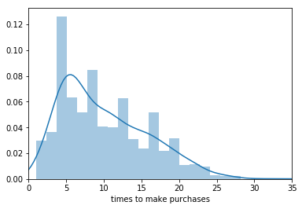

```python
sns.distplot(younger_male_df.groupby('id').size().sort_values(ascending=False));
plt.xlabel('times to make purchases');
plt.xlim(0,35);
# median for times is about 6 times
```

- Male: younger male tend to use and make purchase with offers.Maybe how high income is doesn't matter.
- Female: middle age female tend to use and make purchase with offers. Maybe how high income matters.

# Results

- What kind of group to send offers
  - 60s customers is the big population in this data as we saw before. So it would be better to change the way to send offers from email, mobile, social and web to like paper cards at the checkout etc.
  - the difference of gender doesn't matter a lot.